# Practica12

Última actualización:

10 de mayo de 2026

## Datos

Utilizaremos las medidas de expresión génica del archivo salmon.merged.gene_counts.tsv que podéis descargar en este enlace o en el aula virtual. Los datos proceden de 12 genotecas de RNA-seq de lecturas emparejadas, de muestras de Drosophila melanogaster de dos orígenes geográficos (Panamá y Maine) y dos tratamientos de temperatura (low y high) (Zhao 2015). Hay 3 réplicas biológicas para cada combinación de región y temperatura. Si tenéis curiosidad sobre cómo se han obtenido los recuentos de lecturas por gen a partir de los archivos FASTQ, podéis consultarlo en este enlace.

Además, necesitáis el archivo dme_elev_samples.tsv, una tabla que indica a qué región y tratamiento pertenece cada muestra. Lo podéis descargar de este enlace o del aula virtual.

Los dos archivos deben estar guardados en la carpeta de datos.

## Exploración de datos

```r
muestras <- read.table('../../data/dme_elev_samples.tsv', header = TRUE)
genex <- read.table('../../data/salmon.merged.gene_counts.tsv',
                    header = TRUE)
```

**Ejercicio 1**

Recuerda dejar constancia en un bloque de código de cómo obtienes las respuestas.

**Usa la función paste() para añadir una columna a muestras que contenga la población y la temperatura unidas por _.**

```r
help("paste")
```

```r
paste(muestras$population, muestras$temp, sep = "_")
```

```
 [1] "maine_low"   "maine_low"   "maine_low"   "maine_high"  "maine_high"
 [6] "maine_high"  "panama_low"  "panama_low"  "panama_low"  "panama_high"
[11] "panama_high" "panama_high"
```

```r
#Ahora para crear una nueva columna:
muestras$unido <- paste(muestras$population, muestras$temp, sep = "_")
muestras
```

```
       sample population temp       unido
1  SRR1576457      maine  low   maine_low
2  SRR1576458      maine  low   maine_low
3  SRR1576459      maine  low   maine_low
4  SRR1576460      maine high  maine_high
5  SRR1576461      maine high  maine_high
6  SRR1576462      maine high  maine_high
7  SRR1576463     panama  low  panama_low
8  SRR1576464     panama  low  panama_low
9  SRR1576465     panama  low  panama_low
10 SRR1576514     panama high panama_high
11 SRR1576515     panama high panama_high
12 SRR1576516     panama high panama_high
```

**¿Cuál es el número total de lecturas por muestra?**

```r
total_lecturas <- colSums(genex[ , -c(1,2)])
total_lecturas
```

```
SRR1576457 SRR1576458 SRR1576459 SRR1576460 SRR1576461 SRR1576462 SRR1576463
  28252778   21565448   29471559   27692134   26953900   29368135   29706071
SRR1576464 SRR1576465 SRR1576514 SRR1576515 SRR1576516
  26757043   26596118   30950499   25563787   24401671
```

**¿Los recuentos tienen distribuciones parecidas entre muestras?**

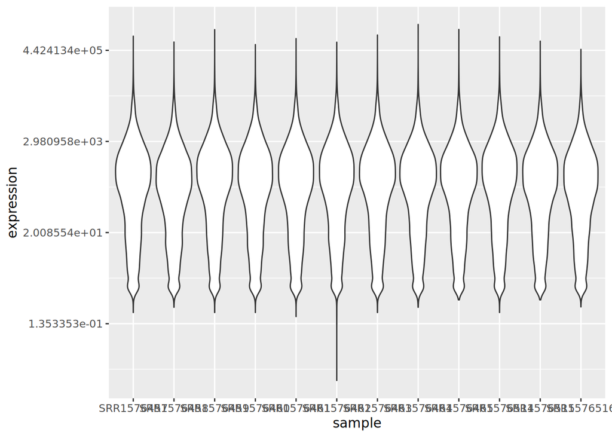

```r
library(tidyr)
library(ggplot2)
genex_long <- pivot_longer(
  genex, 3:14, names_to = "sample",
  values_to = "expression"
)
ggplot(data= genex_long,
       mapping = aes(x = sample, y = expression)) +
  geom_violin() +
  scale_y_continuous(trans ="log")
```

Enviar los nombres de las columnas a una nueva variable y las expresiones también. Ya le podemos decir que la x sea la muestra y la y la expresión.

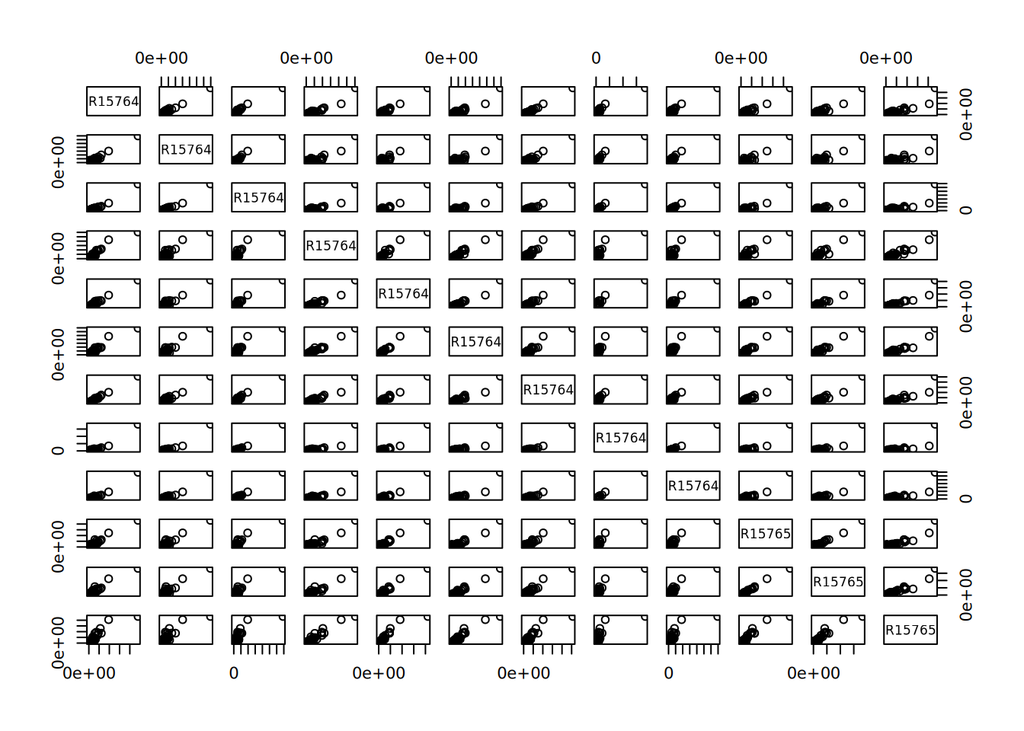

```r
pairs(genex[, -c(1,2)])
```

Es la nube de puntos de cada pareja de columnas, la diagonal es que lo genes con valores altos de expresion en una muestra tambien tienen valores altos de expresion en la otra muestra. Se concentran todos los puntos en la esquina inferior izquierda porque tienen muy poca expresion.  
**¿Cuántos genes no se expresan en absoluto en ninguna de las muestras?**

```r
genes_no_expresados <- sum(rowSums(genex[, -c(1,2)]) ==0)
genes_no_expresados
```

```
[1] 4722
```

## Crear el objeto de clase DESeqDataset

Para crear un objeto de clase DESeqDataSet necesitamos que las filas de la tabla muestras estén en el mismo orden que las columnas en genex. La función DESeqDataSetFromMatrix() necesita que los recuentos sean una matriz, no un marco de datos. Y en muestras debe haber factores.

```r
suppressMessages(library('DESeq2'))
all(names(genex)[3:14] == muestras$sample)
```

```
[1] TRUE
```

```r
# Pasamos la columna "sample" a nombres de fila:
row.names(muestras) <- muestras$sample
# Eliminamos la columna "sample":
muestras$sample <- NULL
# Y convertimos "population" y "temp" en factores:
muestras$population <- factor(muestras$population,
                              levels = c('maine', 'panama'))
muestras$temp       <- factor(muestras$temp,
                              levels = c('low', 'high'))
muestras
```

```
           population temp       unido
SRR1576457      maine  low   maine_low
SRR1576458      maine  low   maine_low
SRR1576459      maine  low   maine_low
SRR1576460      maine high  maine_high
SRR1576461      maine high  maine_high
SRR1576462      maine high  maine_high
SRR1576463     panama  low  panama_low
SRR1576464     panama  low  panama_low
SRR1576465     panama  low  panama_low
SRR1576514     panama high panama_high
SRR1576515     panama high panama_high
SRR1576516     panama high panama_high
```

Los datos de recuento deben ser números enteros y en forma de matriz

```r
row.names(genex) <- genex$gene_name
genex$gene_name <- NULL
genex$gene_id   <- NULL
genex <- round(as.matrix(genex))
```

```r
dds1 <- DESeqDataSetFromMatrix(
   countData = genex,
   colData = muestras,
   design = ~ population + temp
)
dds1
```

```
class: DESeqDataSet
dim: 24254 12
metadata(1): version
assays(1): counts
rownames(24254): 7SLRNA:CR32864 a ... RR51477 Bari1{}RR51478
rowData names(0):
colnames(12): SRR1576457 SRR1576458 ... SRR1576515 SRR1576516
colData names(3): population temp unido
```

## Prefiltrado

Una fracción importante de genes no se están expresando en ningúna muestra. Aunque el filtrado no es necesario, ayuda a reducir la memoria ocupada por dds1:

```r
keep <- rowSums(counts(dds1)) > 0
dds1 <- dds1[keep, ]
```

## Expresión diferencial

```r
dds1 <- DESeq(dds1)
```

```r
res <- results(dds1)
res
```

```
log2 fold change (MLE): temp high vs low
Wald test p-value: temp high vs low
DataFrame with 19508 rows and 6 columns
                baseMean log2FoldChange     lfcSE       stat      pvalue
               <numeric>      <numeric> <numeric>  <numeric>   <numeric>
7SLRNA:CR32864   346.333      0.5918974 1.3301901   0.444972 0.656339979
a                555.596     -0.2730041 0.0718487  -3.799710 0.000144866
abd-A            531.996     -0.0286785 0.0789218  -0.363379 0.716321732
Abd-B            634.760     -0.1083918 0.0771241  -1.405421 0.159896272
Abl             1654.842     -0.1328055 0.0746580  -1.778851 0.075264257
...                  ...            ...       ...        ...         ...
RR51007          4.90906      3.8596869  2.972471  1.2984773 1.94123e-01
RR51048         16.60710     -0.8973071  0.341603 -2.6267541 8.62036e-03
RR51093         36.93279      0.0660523  1.685323  0.0391927 9.68737e-01
RR51475        159.62678     -2.6058194  1.875172 -1.3896429 1.64637e-01
RR51477         70.83394      1.6927986  0.192437  8.7966393 1.40975e-18
                      padj
                 <numeric>
7SLRNA:CR32864  0.81170166
a               0.00154573
abd-A           0.85146289
Abd-B           0.33849217
Abl             0.20046220
...                    ...
RR51007        3.82417e-01
RR51048        4.01745e-02
RR51093        9.84464e-01
RR51475        3.44815e-01
RR51477        2.06427e-16
```

Por defecto, la función results() produce la tabla de resultados para el contraste entre el nivel último y el de referencia del último factor en la tabla que describe las muestras. En este caso, el factor es temp, el nivel de referencia es low y el otro nivel es high. Por tanto, los valores de log2FoldChange representan el logaritmo en base 2 de la relación entre niveles de expresión en muestras high respecto de muestras low.

**Ejercicio 3**

**Mira la ayuda de results() y genera también la tabla de resultados para el contraste entre las dos regiones de procedencia de las moscas.**

```r
help("results")
```

```r
dds2 <- DESeqDataSetFromMatrix(
  countData = genex,
  colData = muestras,
  design = ~ population
)
dds2
```

```
class: DESeqDataSet
dim: 24254 12
metadata(1): version
assays(1): counts
rownames(24254): 7SLRNA:CR32864 a ... RR51477 Bari1{}RR51478
rowData names(0):
colnames(12): SRR1576457 SRR1576458 ... SRR1576515 SRR1576516
colData names(3): population temp unido
```

```r
keep <- rowSums(counts(dds2)) > 0
dds2 <- dds2[keep, ]
```

```r
dds2 <- DESeq(dds2)
```

```r
res2 <- results(dds2)
res2
```

```
log2 fold change (MLE): population panama vs maine
Wald test p-value: population panama vs maine
DataFrame with 19508 rows and 6 columns
                baseMean log2FoldChange     lfcSE       stat     pvalue
               <numeric>      <numeric> <numeric>  <numeric>  <numeric>
7SLRNA:CR32864   346.333     -0.3405225 1.2828671  -0.265439  0.7906716
a                555.596     -0.1061901 0.1079132  -0.984033  0.3250994
abd-A            531.996      0.0468148 0.0780163   0.600065  0.5484628
Abd-B            634.760     -0.0386942 0.0827328  -0.467701  0.6399985
Abl             1654.842     -0.1435019 0.0846880  -1.694478  0.0901746
...                  ...            ...       ...        ...        ...
RR51007          4.90906      1.0441599  2.913048  0.3584424 0.72001228
RR51048         16.60710     -1.2841124  0.397258 -3.2324379 0.00122739
RR51093         36.93279     -0.8907347  1.591194 -0.5597901 0.57562259
RR51475        159.62678     -0.0858284  1.937892 -0.0442896 0.96467360
RR51477         70.83394     -0.2603940  0.461897 -0.5637486 0.57292520
                    padj
               <numeric>
7SLRNA:CR32864  0.966622
a               0.790762
abd-A           0.907772
Abd-B           0.928931
Abl             0.523390
...                  ...
RR51007        0.9498358
RR51048        0.0472064
RR51093        0.9181683
RR51475        0.9967946
RR51477        0.9169334
```

**Usa summary() sobre los resultados para ver el número de genes diferencialmente expresados entre cada par de condiciones.**

```r
summary(res)
```

```
out of 19508 with nonzero total read count
adjusted p-value < 0.1
LFC > 0 (up)       : 2418, 12%
LFC < 0 (down)     : 2336, 12%
outliers [1]       : 90, 0.46%
low counts [2]     : 3018, 15%
(mean count < 2)
[1] see 'cooksCutoff' argument of ?results
[2] see 'independentFiltering' argument of ?results
```

```r
summary(res2)
```

```
out of 19508 with nonzero total read count
adjusted p-value < 0.1
LFC > 0 (up)       : 350, 1.8%
LFC < 0 (down)     : 351, 1.8%
outliers [1]       : 46, 0.24%
low counts [2]     : 2270, 12%
(mean count < 1)
[1] see 'cooksCutoff' argument of ?results
[2] see 'independentFiltering' argument of ?results
```

El factor que mas afecta es la temperatura. **¿Cuál es la tasa de falsos positivos (FDR)?** Es 0.1, se ve del summary En la función results hay un parametro que es alpha, que es el umbral de significancia utilizado. Podemos utilizar un 5%.

## Graficas

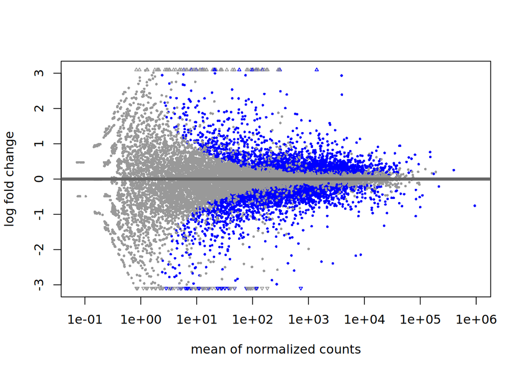

```r
plotMA(res)
```

```r
resShrink <- lfcShrink(dds1, coef = 'temp_high_vs_low',
                       type = 'normal')
```

```
using 'normal' for LFC shrinkage, the Normal prior from Love et al (2014).

Note that type='apeglm' and type='ashr' have shown to have less bias than type='normal'.
See ?lfcShrink for more details on shrinkage type, and the DESeq2 vignette.
Reference: https://doi.org/10.1093/bioinformatics/bty895
```

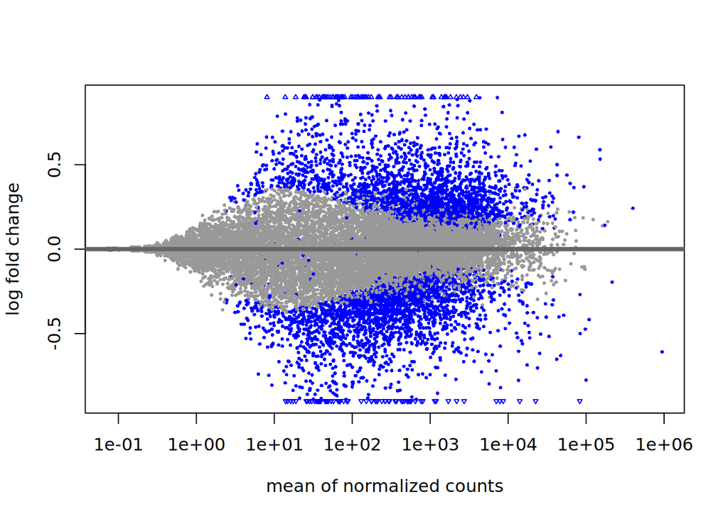

```r
plotMA(resShrink)
```

**Ejercicio 4**

**¿Sabrías hacer una gráfica volcán?**

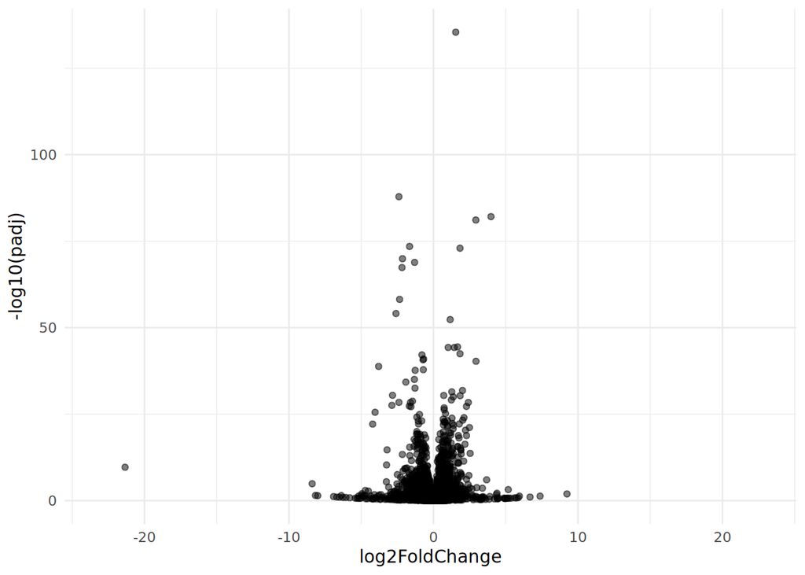

```r
library(ggplot2)
res_df <- as.data.frame(res)
ggplot(res_df, aes(x = log2FoldChange, y = -log10(padj))) +
  geom_point(alpha = 0.5) +
  theme_minimal()
```

## Extraer datos transformados

Aunque los datos de entrada no deben estar normalizados y la función DESeq() ya tiene en cuenta las diferencias de tamaño de genoteca entre muestras y la relación entre media y varianza, puede ser útil disponer de los datos normalizados para representarlos gráficamente. Para ello podemos usar las funciones vst() y assay():

```r
dds3 <- vst(dds1)
NormCounts <- assay(dds3)
```

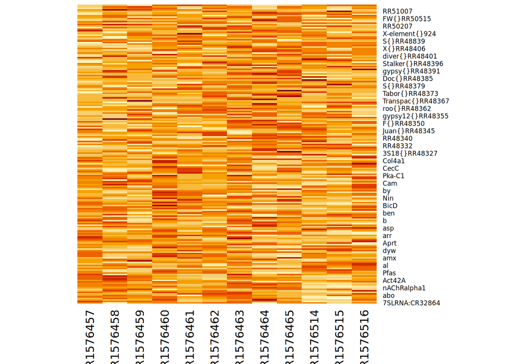

```r
res3 <- res[! is.na(res$pvalue), ]
res3 <- res[order(res$log2FoldChange),]
heatmap(NormCounts[c(head(row.names(res), 100),
                     tail(row.names(res), 100)), ],
        Rowv = NA, Colv = NA)
```

## Ejercicio 5